# Text mining with R and its application to song lyrics

September 10, 2015

## Introduction

Data Scientist for Trinity Health

- Healthcare
  - complex and somewhat deep data
  - LOTS of reporting ("how many patients with diabetes?")
  - predicting bad outcomes based on previous events
- Background: PhD in Bioinformatics
  - Regulation of gene expression
  - Next-generation sequencing data
  - over 1B reads between 50 and 300 bases
  - Deep but not complex data

## Outline

- Creating corpus with `tm`
- Visualization techniques for text
- Clustering with `cluster`
- Topic modeling with `topicmodels`
- Word representations with `word2vec`

## Motivation

Text is everywhere!

- Twitter –> 200M tweets/day * 25 words/tweet = 5B words/day!
- Facebook –> 55M status updates/day
- Amazon –> customer reviews
- Healthcare
  - Clinical notes ("family history of high cholesterol")
  - Event descriptions ("patient slipped and fell")

## Text source

Song lyrics!

- Band of choice: TOOL
- 5 albums
- famously mysterious, ambiguous lyrics

[figure not shown]

[figure not shown]

First, it's a good idea to have this in your .Rprofile:

```r
options(stringsAsFactors = FALSE)
```

Then, create functions to access musiXmatch API:

- requires API key
- artist search to get ID
- get all album IDs
- using artist ID and album IDs, get track IDs
- get lyrics from track IDs

```r
call = paste("http://api.musixmatch.com/ws/1.1/track.lyrics.get?",
              "track_id=", track,
              "&apikey=", apikey,
              "&format=xml", sep = "")

xml <- xmlParse(call)

lyrics <- tryCatch(xmlToDataFrame(nodes=getNodeSet(xml, "//lyrics_body")),
                   error = function(e) print("NA"))
```

## Creating a collection of lyrics

```r
get_corpus <- function(artist, apikey){

  #get albums for particular artist
  albums <- get_albums(artist, apikey)

  #loop through albums
  tracks <- lapply(albums, get_tracks, apikey) %>% unlist()

  #loop through tracks
  lyrics <- lapply(tracks, get_lyrics, apikey) %>% unlist()

  obj <- list(lyrics = data.frame(lyrics),
              n_albums = length(albums),
              n_tracks = length(tracks))

  return(obj)
}

collection <- get_corpus(artist, apikey)
```

## Creating a corpus with `tm`

## Clean up text and build corpus

```r
removeURL <- function(x) gsub("http[[:alnum:]]*", "", x)

collection$lyrics %<>% sapply(., function(x) str_replace_all(x, "[^[:alnum:] ]", ""))

custom_stopwords <- c(stopwords("english"), other) %>%
  sapply(., function(x) gsub("[[:punct:]]", "", x), simplify = "array", USE.NAMES = F)

corpus <- Corpus(VectorSource(collection$lyrics)) %>%
  tm_map(content_transformer(tolower)) %>%
  tm_map(stripWhitespace) %>%
  tm_map(removePunctuation) %>%
  tm_map(removeNumbers) %>%
  tm_map(removeURL) %>%
  tm_map(removeWords, custom_stopwords) %>%
  tm_map(stemDocument) %>%
  tm_map(PlainTextDocument)

tdm <- corpus %>%
  TermDocumentMatrix(control = list(minWordLength = 3))

dtm <- as.DocumentTermMatrix(tdm)
```

## Term frequency

```r
term.freq <- slam::row_sums(tdm, na.rm = T)
high.freq <- sort(term.freq, decreasing = T)[1:20]

freq.terms <- names(high.freq)
```

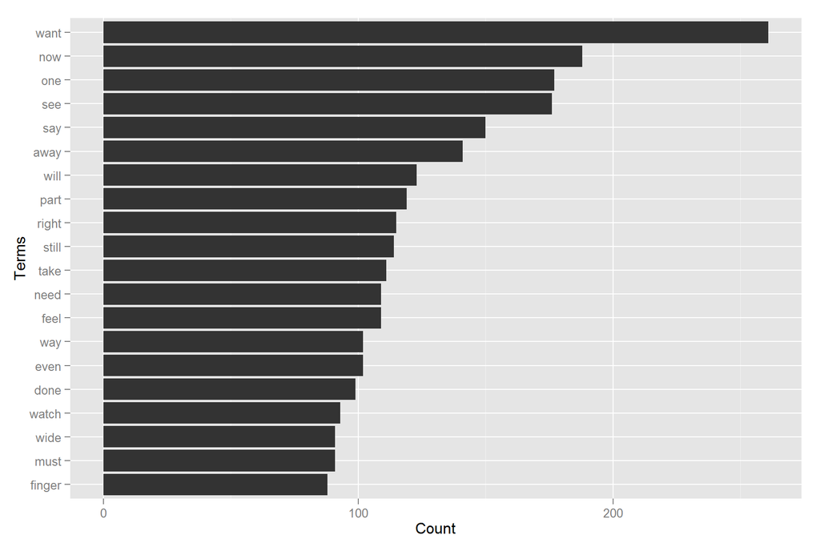

```r
df <- data.frame(term = names(high.freq), freq = high.freq)
df$term <- factor(df$term, levels = df$term[order(df$freq)])

ggplot(df, aes(x = term, y = freq)) +
  geom_bar(stat = "identity") +
  xlab("Terms") +
  ylab("Count") +
  coord_flip()
```

## Visualization techniques for text

## (obligatory) Word cloud

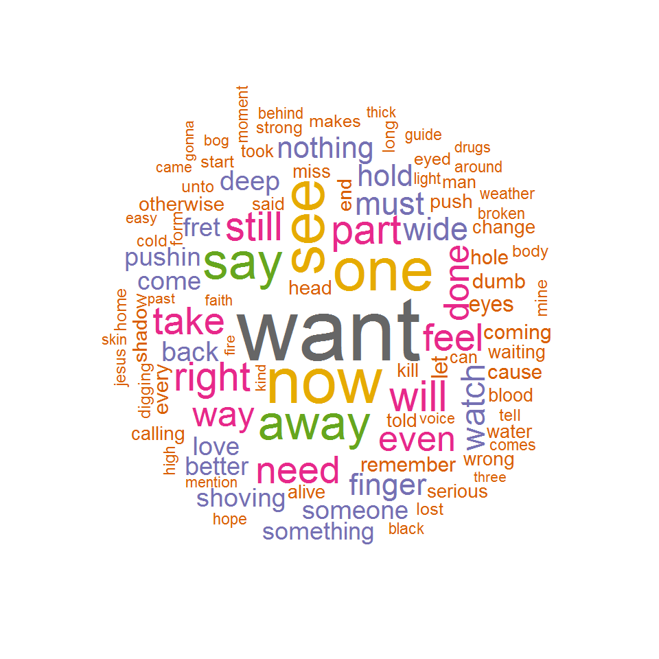

```r
word.freq <- sort(term.freq, decreasing = T)[1:100]
pal2 <- brewer.pal(8, "Dark2")

wordcloud(words = names(word.freq),
          freq = word.freq,
          scale = c(4, 0.1),
          colors = pal2,
          rot.per = 0.15,
          random.color = F,
          random.order = F)
```

## Network of correlated words

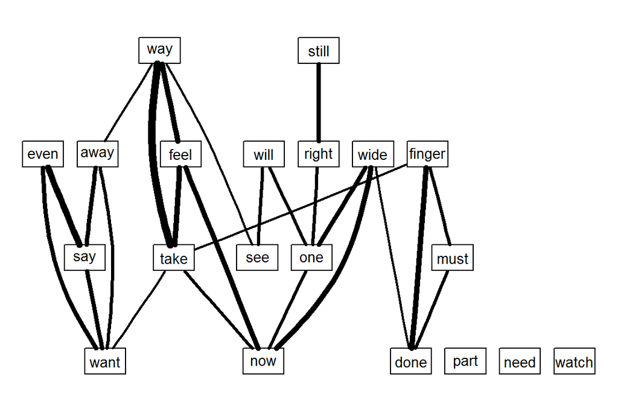

```r
plot(tdm,
     term = freq.terms,
     corThreshold = 0.2,
     weighting = T)
```

## Clustering with `cluster`

## k-means clustering

- unsupervised learning
- group **n** documents into **k** clusters

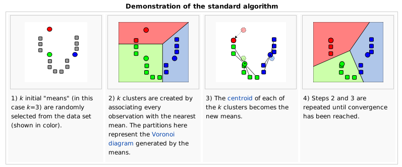

## Weighting terms for clustering

- term frequency-inverse document frequency (tf-idf)
- offset by term frequency in the corpus

Example: N = # documents, d = # documents with term

- "information content" of a term: log(N/d)
  - rare term = high idf: log(100/4) = 4.64
  - common term = low idf: log(100/60) = 0.74

```r
tdm_tfxidf <- weightTfIdf(tdm)

d <- stats::dist(t(tdm_tfxidf), method = "euclidian")

k <- 15

set.seed(12345)
kmean <- kmeans(d, k)

kmean$betweenss/kmean$totss
```

```
## [1] 0.8028445
```

## Automatic labeling of clusters

```r
for(i in 1:k){
  inGroup <- slam::row_means(tdm_tfxidf[, kmean$cluster == i])

  words <- names(sort(inGroup, decreasing = T)[1:5])

  cat("Cluster ", i, ": ", words, "\n")
}
```

```
## Cluster  1 :  let take way back another
## Cluster  2 :  satan kinda anyway engine funny
## Cluster  3 :  others unto done young bit
## Cluster  4 :  mine suck comfort calling man
## Cluster  5 :  beyond infancy lines reaching white
## Cluster  6 :  say serious even want pushin
## Cluster  7 :  part better mention weather scars
## Cluster  8 :  punishment cure wrong someone told
## Cluster  9 :  bog easy thick lost belligerent
## Cluster  10 :  fret arizona bay circus fix
## Cluster  11 :  want away eleven frightened broken
## Cluster  12 :  need bear belong borderline boredoms
## Cluster  13 :  abominatio ache acid across acts
## Cluster  14 :  every comfortable twice past whistle
## Cluster  15 :  eyed form hold wide one
```

## Topic modeling with `topicmodels`

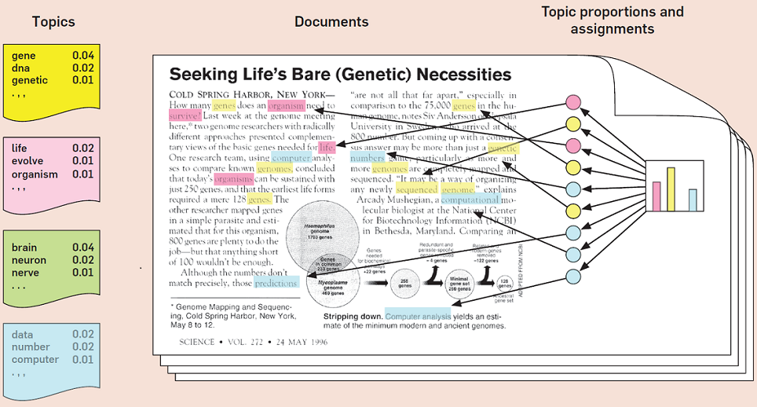

Blei, 2012, Communications of the ACM

```r
doc.freq <- slam::row_sums(dtm, na.rm = T)

dtm_subset <- dtm[doc.freq > 0, ]

set.seed(56789)
lda <- LDA(dtm_subset, k, method = "Gibbs")
topics <- terms(lda, 5)

topics
```

```
##      Topic 1         Topic 2   Topic 3   Topic 4      Topic 5
## [1,] "part"          "weather" "want"    "kinda"      "around"
## [2,] "see"           "change"  "say"     "satan"      "deep"
## [3,] "better"        "drugs"   "even"    "scared"     "voice"
## [4,] "will"          "mention" "away"    "frightened" "comfortable"
## [5,] "communication" "shadow"  "serious" "right"      "twice"
##      Topic 6     Topic 7  Topic 8 Topic 9 Topic 10 Topic 11  Topic 12
## [1,] "done"      "now"    "fret"  "hold"  "take"   "need"    "still"
## [2,] "something" "makes"  "see"   "one"   "way"    "guide"   "pushin"
## [3,] "finger"    "broken" "time"  "wide"  "feel"   "follow"  "shoving"
## [4,] "every"     "see"    "day"   "now"   "kill"   "someone" "love"
## [5,] "come"      "poison" "snake" "will"  "let"    "ein"     "right"
##      Topic 13  Topic 14 Topic 15
## [1,] "calling" "must"   "watch"
## [2,] "eleven"  "miss"   "told"
## [3,] "come"    "one"    "wrong"
## [4,] "please"  "gonna"  "lost"
## [5,] "pure"    "lot"    "bog"
```

## Bonus round: word2vec, AKA Skynet for NLP

## What is word2vec?

- Neural network
  - learns word representation <–> word
- Continuous bag of words
  - Input: w[i-2], w[i-1], w[i+1], w[i+2]
  - Output: w[i]
  - Predict word(s) given a context
- Skip-gram
  - Input: w[i]
  - Output: w[i-2], w[i-1], w[i+1], w[i+2]
  - Predict the context given word(s)

[figure not shown]

Clean up text to prepare for training

```
perl -pe 's/[^A-Za-z \n]//g' lyrics.txt | perl -ne 'print lc' > lyrics_clean.txt

word2vec -train lyrics_clean.txt
         -output lyrics.bin
         -cbow 0
         -size 40
         -window 5
         -negative 5
         -hs 0
         -sample 1e-4
         -threads 2
         -binary 1
         -iter 15
```

gensim: Python API for word2vec

```
import gensim

model = gensim.models.Word2Vec.load_word2vec_format('lyrics.bin', binary=True)
```

## Words most similar to "sober"

```
model.most_similar(positive=['sober'],topn=10)
```

[(u'drink', 0.9925556778907776),  
(u'forever', 0.9861373901367188),  
(u'worthless', 0.9771038293838501),  
(u'liar', 0.9750714898109436),  
(u'start', 0.9736068844795227),  
(u'past', 0.9666637182235718),  
(u'whistle', 0.9328956007957458),  
(u'jesus', 0.9014797806739807),  
(u'cant', 0.8932009935379028),  
(u'something', 0.8820810914039612)]

Sober  
"Why can't we not be sober"  
"I am just a worthless liar"

## Word algebra: "shadow" - "shrouding"

```
model.most_similar(positive=['shadow'],negative=['shrouding'],topn=10)
```

[(u'shadows', 0.6374932527542114),  
(u'scabs', 0.6287078857421875),  
(u'join', 0.6279171705245972),  
(u'shedding', 0.6278539299964905),  
(u'picking', 0.6239765286445618),  
(u'numb', 0.6163206696510315),  
(u'through', 0.6030178666114807),  
(u'child', 0.6013140678405762),  
(u'skin', 0.5950607061386108),  
(u'muscles', 0.5946651697158813)]

46 & 2  
"My shadow's shedding skin"  
"I've been picking my scabs again"

Sober  
"There's a shadow just behind me"  
"Shrouding every step I take"

## "pieces" + "fit"

```
model.most_similar(positive=['pieces','fit'],topn=10)
```

[(u'cuz', 0.9940807223320007),  
(u'watched', 0.9926615357398987),  
(u'tumble', 0.969153106212616),  
(u'crippling', 0.9584764838218689),  
(u'fault', 0.9492095112800598),  
(u'fall', 0.9391438364982605),  
(u'communication', 0.9290061593055725),  
(u'none', 0.9206214547157288),  
(u'mildewed', 0.9142787456512451),  
(u'cannot', 0.8897439241409302)]

Schism  
"I know the pieces fit, cuz I watched them tumble down"  
"No fault, none to blame"  
"Crippling our communication"

## Acknowledgements

Thank you very much for your attention!

**Resources**

gensim: https://radimrehurek.com/gensim/index.html

word2vec demystified: http://alexminnaar.com/

major R packages: `tm`, `topicmodels`, `slam`

[figure not shown]